# Bilgi Yönetim Sistemleri - Bitirme Projesi Rapor : Süleyman Oruç 190401026

## Q1: İş probleminin tanımı

*DataHormony* Şirketi’nin satış verilerinin analizi ve tahmini üzerine bir iş problemi ele alınmıştır. **Amacımız**, geçmiş satış verilerini kullanarak gelecekteki satış trendlerini öngörmek ve stratejik kararları daha bilinçli bir şekilde almaktır.Kullandığımız İş Zekası (BYS) platformu SuiteCRM, müşteri ilişkileri yönetimi konusunda sunduğu özelleştirilebilir modüller, açık kaynak kodlu yapısı ve güçlü raporlama araçlarıyla öne çıkmaktadır. SuiteCRM’nin gelişmiş raporlama ve analiz özelliklerinden yararlanarak özelleştirilebilir raporlar ve dashboardlar oluşturacağız. Bu sayede müşteri ve satış verilerini merkezi bir şekilde yönetip, çeşitli veri kaynaklarını bütüncül bir şekilde analiz edebileceğiz.

## Q2: İş problemini çözmede kullanılacak data seti

*DataHarmony* ekibi olarak kullandığımız veri seti şirketimizin hizmet verdiği *Shock Bank* kullanıcılarının bilgilerini içermektedir. Veri setinde 5000 kullanıcı verisi ile birlikte her kullanıcıya ait 13 adet özellik bulunmaktadır. Bu özellikler farklı sütunlarda listelenmektedir.

### Veri setimizde ki kullanıcı özellikleri:

Projede kullanılan veri seti Kaggle platformunda ki 4 farklı veri setinden alınmış özellikleri barındırır.

### Kullanılan veri setlerinin adresleri ve hangi sütun bilgilerinin kullanıldığı:

- *https://www.kaggle.com/datasets/thedevastator/predicting-credit-card-customer-attrition-with-m*

**Veri setinden kullanılan sütun bilgileri:** Müşteri Numarası , Yaş , Hesap Sayısı , Medeni Durum , Gelir , Kart Kategorisi , Kredi Limiti

**Veri setinin oluşturulması :** Bu veri seti **https://zenodo.org/record/4322342#.Y8OsBdJBwUE** adresinden scraping yöntemi ile oluşturulmuştur

- *https://www.kaggle.com/datasets/shivamb/bank-customer-segmentation*

**Veri setinden kullanılan sütun bilgileri:** Doğum Tarihi , İşlem Tarihi

**Veri setinin oluşturulması :** Bu veri seti, Hindistan’daki bir bankadan alınmıştır.

- *https://www.kaggle.com/datasets/iamsouravbanerjee/customer-segmentation-51k-records*

**Veri setinden kullanılan sütun bilgileri:** İsim , Soyisim , Email

**Veri setinin oluşturulması :** Bu veri seti **https://www.mockaroo.com/** sitesinden oluşturulmuş sahte verileri içerir.

- *https://www.kaggle.com/datasets/mokar2001/tehran-easytoremember-phone-number-price*

**Veri setinden kullanılan sütun bilgileri:** Telefon Numarası

**Veri setinin oluşturulması :** Bu veri setine ait tüm veriler rond.ir’e aittir. Bu verileri toplamak için python ve tarama tekniğini kullanılmıştır.

## Q3: Veri seti keşifsel analizi

### Projemizde bulunan sorunu çözmek için kullanılacak veri setinde ki önemli sütunlar:

- **İşlem Tarihi** : Character veri tipindedir.
- **Hesap Sayısı** : Numeric veri tipindedir.
- **Kart Kategorisi** : Character veri tipindedir.
- **Gelir** : Numeric veri tipindedir.
- **Kredi Limiti** : Numeric veri tipindedir.

### Veri setinde yapılan ön işleme operasyonları:

- Gelir ve Medeni Durum sütunlarında ki “unknown” ve Doğum Günü sütununda ki “nan” olarak belirtilmiş eksik veriler R programlama dilinde yapılacak işlemlerde sorun yaratmaması için “NA” formatına dönüştürüldü.
- Gelir sütununda ki character veriler numeric verilere dönüştürüldü.
- Gelir sütununda bulunan eksik veriler ilgili grubun ortalaması ile dolduruldu.
- Medeni Durum ve Doğum Günü sütunlarında ki eksik verilerin oranı çok düşük olduğu için bir işlem yapılmadı.
- Medeni Durum ve Kart Kategorisi sütunlarında bulunan anlamsız veriler anlamlı hale getirildi.
- Veri setinde ki sütun isimleri anlaşılır hale getirildi.

### VERİ SETİ İSTATİSTİĞİ

**Ortalama Gelir - Yas Tablosu:**

| Yas | ortalama_gelir |
| --- | --- |
| 26 | 58187.02 |
| 27 | 63479.87 |
| 28 | 58829.11 |
| 29 | 64206.16 |
| 30 | 83181.48 |
| 31 | 66561.21 |
| 32 | 61694.57 |
| 33 | 71232.02 |
| 34 | 68209.47 |
| 35 | 65271.29 |

[output cut: 33 more lines]

Yukarıda ki tabloda veri setimizde yaşa göre gelir ortalamaları gösterilmektedir.

**Ortalama Gelir - Yas Grafiği:**

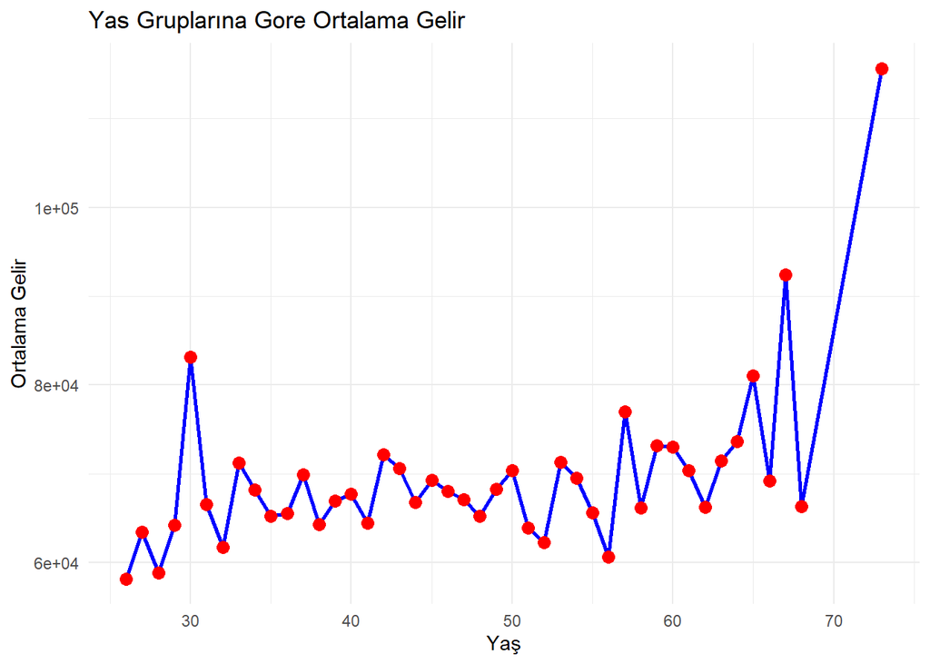

Yukarıda ki grafikte veri setimizde yaşa göre gelir ortalamaları gösterilmektedir.

**Kart Kategorisi Pasta Grafiği:**

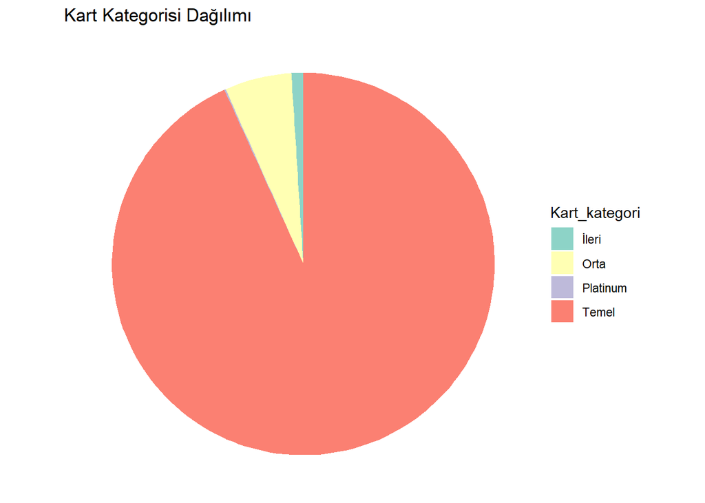

Yukarıda ki pasta grafiğinde kart kategorisinin dağılımı gösterilmektedir.

Elde edilen grafikte de görüldüğü üzere “Temel” kart kategorisine sahip kişiler çoğunluktadır. Buradan da anlaşıldığı üzere *Shock Bank* müşterilerine karşı risk almadığı bir politika izlemektedir.

## Q4: Veri setinin BYS platformuna ithali

Projede kullanılacak veri seti, CSV formatında olup, SuiteCRM bilgi yönetim sisteminde oluşturulan modülün “import” özelliği kullanılarak entegre edilmiştir. Bu süreçte, SuiteCRM’in veri entegrasyon araçları ve modül tabanlı yapılandırma özellikleri etkin bir şekilde kullanılmıştır. Verilerin doğru ve tutarlı bir şekilde aktarılması için CSV dosyalarının formatı, sistem gereksinimlerine uygun olarak düzenlenmiş ve veri temizleme işlemleri uygulanmıştır. Bu entegrasyon, projenin veri analiz ve işleme aşamalarında kullanılmak üzere güvenilir ve erişilebilir bir veri kaynağı sağlamaktadır.

## Q5 : Yapılması planlanan veri analizi

Projenin son bölümünde yapılması planlanan 2 adet analiz vardır. Yapılması planlanan ilk analiz veri setinde ki *işlem tarihi* sütununda bulunan verilere göre bankada gerçekleştirilen işlemlerin yoğunluğu belirlenecektir. Bu işlem sonucunda bankanın çalışan sayısını optimum düzeyde tutması ve giderlerinin azaltılması hedeflenmektedir.

### Sentetik Veri Üretimi ve Kredi Tahmin Modeli ile Risk Yönetimi

Bu çalışmada, banka müşterilerinin kredi başvurularının değerlendirilmesi ve gereksiz risklerin minimize edilmesi amacıyla bir tahmin modeli geliştirilmiştir. Bu süreç, sentetik veri üretimi, model eğitimi ve entegrasyon aşamalarından oluşmaktadır.

**1. Sentetik Veri Üretimi**

İlk adım olarak, aşağıdaki sütunlardan oluşan bir veri seti sentetik olarak üretilecektir:

- *Medeni Durum*
- *Kart Kategorisi*
- *Hesap Sayısı*
- *Kredi Limiti*
- *Gelir*

Bu sütunlar, rastgele değerler ile oluşturulmuş ve belirli istatistiksel dağılımlara uygun olarak dağıtılacaktır. Örneğin, gelir için 20.000 TL ile 200.000 TL arasında değerler kullanılacaktır.

**2. Kredi Verilip Verilmeyeceğine Dair Koşullar**

Sentetik olarak üretilen verilere, kredi verilip verilmeyeceğine dair belirlenen koşullara göre Kredi_Ver sütunu eklenecektir. Bu sütun, müşterinin kredi alıp almayacağını belirtir ve iki farklı değere sahip olabilir:

**Evet:** Müşteri kredi alabilir.

**Hayır:** Müşteri kredi alamaz.

*Bu koşullar, aşağıdaki kriterlere göre belirlenmiştir:*

Kredi limiti belirli bir eşiğin üzerindeyse (örneğin, 10.000 TL).

Gelir belirli bir miktarın üzerindeyse (örneğin, 50.000 TL).

**3. Tahmin Modeli Oluşturma ve Eğitimi**

Sentetik veri seti kullanılarak bir makine öğrenimi modeli oluşturulacak ve eğitilecektir. Bu model, sınıflandırma algoritmaları kullanılarak geliştirilecektir. Kullanılacak algoritmalar arasında, karar ağaçları (Decision Trees), lojistik regresyon (Logistic Regression), rastgele ormanlar (Random Forests) ve destek vektör makineleri (Support Vector Machines) yer alabilir. Modelin eğitimi ve test edilmesi için veri seti, eğitim ve test veri setleri olarak ikiye ayrılacaktır.

Modelin performansı, doğruluk (accuracy), kesinlik (precision), geri çağırma (recall) ve F1 skoru gibi metrikler kullanılarak değerlendirilecektir.

**4. SuiteCRM Entegrasyonu**

Eğitilen model, bilgi yönetim sistemimiz SuiteCRM ile entegre edilecektir. SuiteCRM’den çekilen müşteri verileri, modelin girdisi olarak kullanılacak ve bu verilere Kredi_Ver sütunu eklenecektir. Bu entegrasyon sayesinde, banka müşterilerinin kredi başvuruları değerlendirilirken, modelin tahminleri doğrultusunda karar verilecektir.

## Q6 : Çalışan platformun gösterildiği sesli anlatımlı video

**Video YouTube linkimiz:**

https://www.youtube.com/watch?v=rKbp2Us0A8E&t=2s